# chapter6

# RStudio Exercise 6: Analysis of longitudinal data

Let’s load the required addons

```r
library(dplyr)
library(tidyr)
library(ggplot2)
library(stringr)
library(lme4)
```

The BPRS data contains data from 40 males, equally assigned to two treatment groups(20 each group). Brief psychiatric scale rating was measured at baseline i.e. before treatment and then every week subsequently, until week 8. BPRS is used to evaluate patients that are suspected of having schizophrenia.

The RATS data is from a nutrition study carried out on RATS. Each group was put on a different diet and their weight was followed for a period of 9 weeks. Measurements were taken every week, except week six when two measurements were taken.

The data in these datasets has been converted into long form. The script for creating long form data can be found in the data folder and the difference between both is explained in the script file.

Let’s read the datasets BPRS and RATS created using the instructions form the data wrangling exercise.

```r
BPRS <- read.csv("https://raw.githubusercontent.com/KimmoVehkalahti/MABS/master/Examples/data/BPRS.txt", sep=" ")
RATS <- read.csv("https://raw.githubusercontent.com/KimmoVehkalahti/MABS/master/Examples/data/rats.txt", sep='\t')


RATSL <- read.table("data/RATSL.csv", sep=",", header=TRUE, check.names=FALSE, row.names = 1)

BPRSL <- read.table("data/BPRSL.csv", sep=",", header=TRUE, check.names=FALSE, row.names = 1)


glimpse(RATSL)
```

```
## Observations: 176
## Variables: 5
## $ ID     <int> 1, 2, 3, 4, 5, 6, 7, 8, 9, 10, 11, 12, 13, 14, 15, 16, ...
## $ Group  <int> 1, 1, 1, 1, 1, 1, 1, 1, 2, 2, 2, 2, 3, 3, 3, 3, 1, 1, 1...
## $ WD     <fct> WD1, WD1, WD1, WD1, WD1, WD1, WD1, WD1, WD1, WD1, WD1, ...
## $ Weight <int> 240, 225, 245, 260, 255, 260, 275, 245, 410, 405, 445, ...
## $ Time   <int> 1, 1, 1, 1, 1, 1, 1, 1, 1, 1, 1, 1, 1, 1, 1, 1, 8, 8, 8...
```

```r
glimpse(BPRSL)
```

```
## Observations: 360
## Variables: 5
## $ treatment <int> 1, 1, 1, 1, 1, 1, 1, 1, 1, 1, 1, 1, 1, 1, 1, 1, 1, 1...
## $ subject   <int> 1, 2, 3, 4, 5, 6, 7, 8, 9, 10, 11, 12, 13, 14, 15, 1...
## $ weeks     <fct> week0, week0, week0, week0, week0, week0, week0, wee...
## $ bprs      <int> 42, 58, 54, 55, 72, 48, 71, 30, 41, 57, 30, 55, 36, ...
## $ week      <int> 0, 0, 0, 0, 0, 0, 0, 0, 0, 0, 0, 0, 0, 0, 0, 0, 0, 0...
```

As the datasets were saved in csv format, after reading, the factor variables have turned into integers. Let’s convert them back to factor variables. This is important, so that the software knows that these are categorical and not a scalar variables.

```r
BPRSL$treatment <- factor(BPRSL$treatment)
BPRSL$subject <- factor(BPRSL$subject)
RATSL$ID <- factor(RATSL$ID)
RATSL$Group <- factor(RATSL$Group)



glimpse(RATSL)
```

```
## Observations: 176
## Variables: 5
## $ ID     <fct> 1, 2, 3, 4, 5, 6, 7, 8, 9, 10, 11, 12, 13, 14, 15, 16, ...
## $ Group  <fct> 1, 1, 1, 1, 1, 1, 1, 1, 2, 2, 2, 2, 3, 3, 3, 3, 1, 1, 1...
## $ WD     <fct> WD1, WD1, WD1, WD1, WD1, WD1, WD1, WD1, WD1, WD1, WD1, ...
## $ Weight <int> 240, 225, 245, 260, 255, 260, 275, 245, 410, 405, 445, ...
## $ Time   <int> 1, 1, 1, 1, 1, 1, 1, 1, 1, 1, 1, 1, 1, 1, 1, 1, 8, 8, 8...
```

```r
glimpse(BPRSL)
```

```
## Observations: 360
## Variables: 5
## $ treatment <fct> 1, 1, 1, 1, 1, 1, 1, 1, 1, 1, 1, 1, 1, 1, 1, 1, 1, 1...
## $ subject   <fct> 1, 2, 3, 4, 5, 6, 7, 8, 9, 10, 11, 12, 13, 14, 15, 1...
## $ weeks     <fct> week0, week0, week0, week0, week0, week0, week0, wee...
## $ bprs      <int> 42, 58, 54, 55, 72, 48, 71, 30, 41, 57, 30, 55, 36, ...
## $ week      <int> 0, 0, 0, 0, 0, 0, 0, 0, 0, 0, 0, 0, 0, 0, 0, 0, 0, 0...
```

### Chapter 8 analyses on RATS dataset

Now we will be working with RATS dataset and as instructed, we will carry out the analyses in chapter 8 of Kimmo’s textbook, but using the RATS dataset instead of BPRS.

Let’s visualize the data.

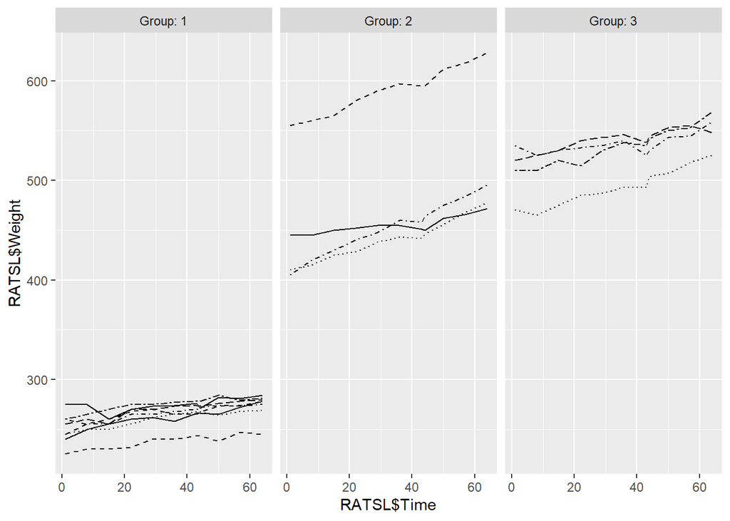

```r
ggplot(RATSL, aes(x = RATSL$Time, y = RATSL$Weight, linetype = ID)) +
  geom_line() +
  scale_linetype_manual(values = rep(1:10, times=4)) +
  facet_grid(. ~ Group, labeller = label_both) +
  theme(legend.position = "none") +
  scale_y_continuous(limits = c(min(RATSL$Weight), max(RATSL$Weight)))
```

Here we can see can already see that within the three groups of rats, there is a difference in baseline weight. We can also see that there is an upward trend for weight in all groups.

What is apparent is that the rats with higher weight continued to have high weight throughout the study. This phenomenon is called tracking and we shall try to visualize it by **“subtracting the relevant occasion mean from the original observation and then dividing by the corresponding visit standard deviation.”** (source, Kimmo’s book)

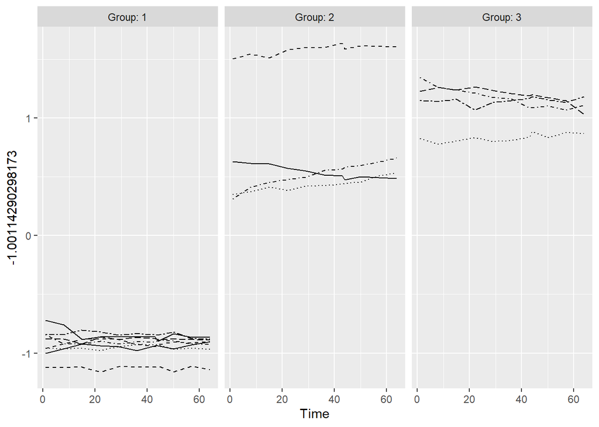

```r
# Standardizing weight
RATSL <- RATSL %>%
  group_by(Time) %>%
  mutate(stdweight = (Weight - mean(Weight))/sd(Weight) ) %>%
  ungroup()



# Plotting again with standardized weight

ggplot(RATSL, aes(x = Time, y = stdweight, linetype = ID)) +
  geom_line() +
  theme(legend.position = "none") +
  scale_linetype_manual(values = rep(1:10, times=4)) +
  facet_grid(. ~ Group, labeller = label_both) +
  scale_y_continuous(name = RATSL$stdweight)
```

The large number of individuals here leave a lot to the imagination though. It would be better is we could draw a more concise plot showing mean profiles for each group, and the variation between these measurements.

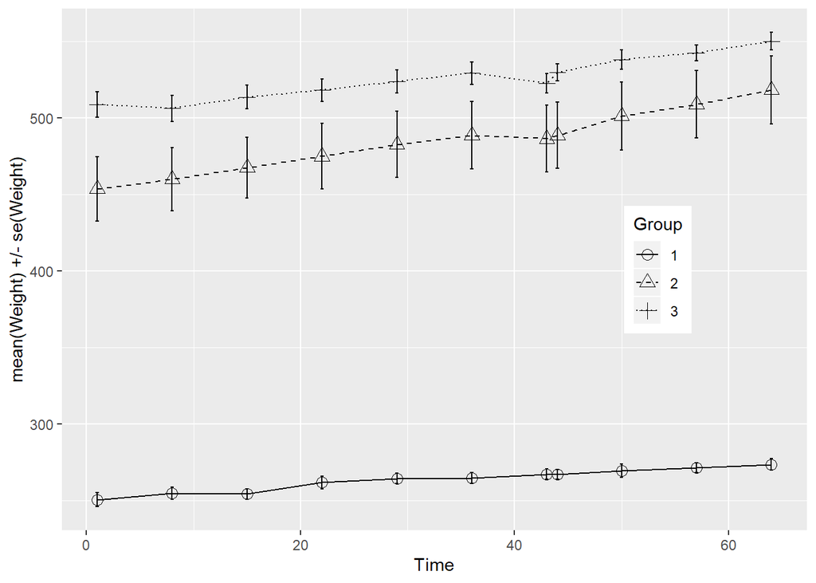

```r
n <- RATSL$Time %>% unique() %>% length()

RATSS <- RATSL %>%
  group_by(Group, Time) %>%
  summarise( mean = mean(Weight), se = (sd(Weight) /
   sqrt(n))) %>%
  ungroup()

# Plotting the mean profiles
ggplot(RATSS, aes(x = Time, y = mean, linetype = Group, shape = Group)) +
  geom_line() +
  scale_linetype_manual(values = c(1,2,3)) +
  geom_point(size=3) +
  scale_shape_manual(values = c(1,2,3)) +
  geom_errorbar(aes(ymin=mean-se, ymax=mean+se, linetype="1"), width=0.3) +
  theme(legend.position = c(0.8,0.5)) +
  scale_y_continuous(name = "mean(Weight) +/- se(Weight)")
```

Another way to visualize data is through boxplots.

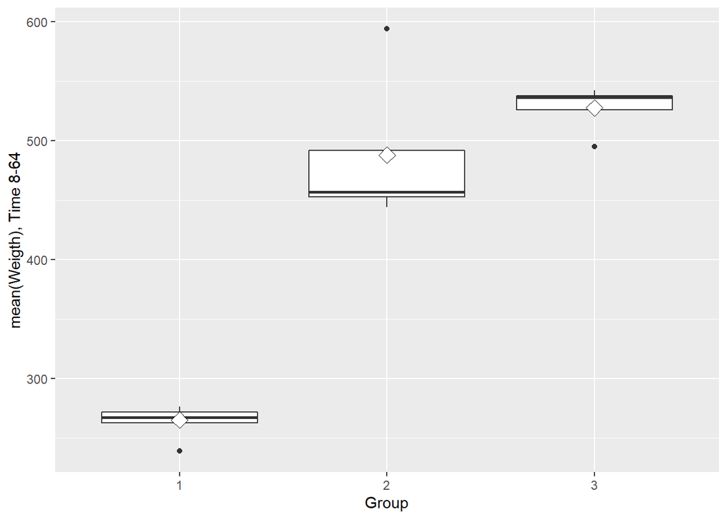

```r
RATSL8S <- RATSL %>%
  filter(Time > 1) %>%
  group_by(Group, ID) %>%
  summarise( mean=mean(Weight) ) %>%
  ungroup()

ggplot(RATSL8S, aes(x = Group, y = mean)) +
  geom_boxplot() +
  stat_summary(fun.y = "mean", geom = "point", shape=23, size=4, fill = "white") +
  scale_y_continuous(name = "mean(Weigth), Time 8-64")
```

We can atleast identify one outlier that is affecting the results. Let’s remove it and redraw the plot.

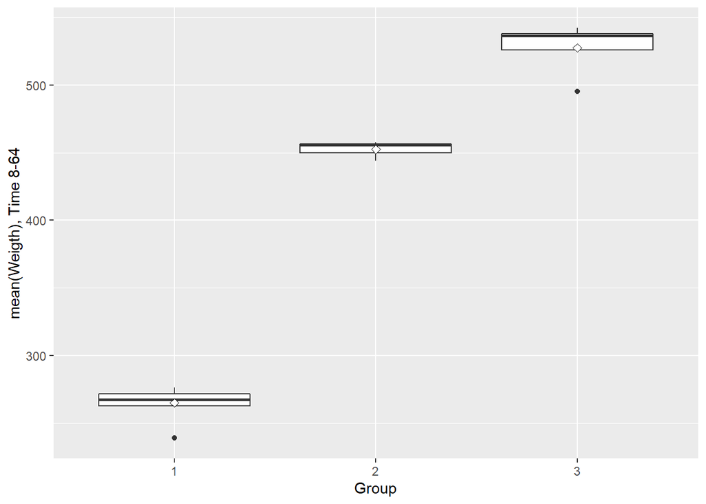

```r
RATSL8S1 <- RATSL8S%>% filter(mean < 590 )



ggplot(RATSL8S1, aes(x = Group, y = mean)) +
  geom_boxplot() +
  stat_summary(fun.y = "mean", geom = "point", shape=23, size=2, fill = "white") +
  scale_y_continuous(name = "mean(Weigth), Time 8-64")
```

Now it is time to run the t test. However, the problem is that t test is meant for comparison between two group, but here we have three groups. We will instead use One-way ANOVA for within group comparison.

```r
RATSL8S1owa <- aov(mean ~ Group, data = RATSL8S1)

summary(RATSL8S1owa)
```

```
##             Df Sum Sq Mean Sq F value   Pr(>F)
## Group        2 207659  103830   501.8 2.72e-12 ***
## Residuals   12   2483     207
## ---
## Signif. codes:  0 '***' 0.001 '**' 0.01 '*' 0.05 '.' 0.1 ' ' 1
```

The results from ANOVA tell us that the groups differ significantly between each other based on weight gain. However to find out which groups are different we need to run a post-hoc analysis.

```r
TukeyHSD(RATSL8S1owa)
```

```
##   Tukey multiple comparisons of means
##     95% family-wise confidence level
##
## Fit: aov(formula = mean ~ Group, data = RATSL8S1)
##
## $Group
##        diff       lwr      upr    p adj
## 2-1 187.375 161.39457 213.3554 0.00e+00
## 3-1 262.475 238.97481 285.9752 0.00e+00
## 3-2  75.100  45.79012 104.4099 4.98e-05
```

But the problem is that we have not adjusted the model for baseline weight. That can be an important factor considering that the rats in group a had a significantly lower weight at the start of the study (as seen in the plots).

Let’s run a linear regression modal with baseline values as of the predictors.

```r
RATS
```

```
##    ID Group WD1 WD8 WD15 WD22 WD29 WD36 WD43 WD44 WD50 WD57 WD64
## 1   1     1 240 250  255  260  262  258  266  266  265  272  278
## 2   2     1 225 230  230  232  240  240  243  244  238  247  245
## 3   3     1 245 250  250  255  262  265  267  267  264  268  269
## 4   4     1 260 255  255  265  265  268  270  272  274  273  275
## 5   5     1 255 260  255  270  270  273  274  273  276  278  280
## 6   6     1 260 265  270  275  275  277  278  278  284  279  281
## 7   7     1 275 275  260  270  273  274  276  271  282  281  284
## 8   8     1 245 255  260  268  270  265  265  267  273  274  278
## 9   9     2 410 415  425  428  438  443  442  446  456  468  478
## 10 10     2 405 420  430  440  448  460  458  464  475  484  496
## 11 11     2 445 445  450  452  455  455  451  450  462  466  472
## 12 12     2 555 560  565  580  590  597  595  595  612  618  628
## 13 13     3 470 465  475  485  487  493  493  504  507  518  525
## 14 14     3 535 525  530  533  535  540  525  530  543  544  559
## 15 15     3 520 525  530  540  543  546  538  544  553  555  548
## 16 16     3 510 510  520  515  530  538  535  542  550  553  569
```

```r
# Creating a new variable
RATSL8S2 <- RATSL8S %>%
  mutate(baseline = RATS$WD1)

# Fit the linear model with the mean as the response
fit <- lm(mean ~ baseline + Group, data = RATSL8S2)

# Compute the analysis of variance table for the fitted model with anova()
anova(fit)
```

```
## Analysis of Variance Table
##
## Response: mean
##           Df Sum Sq Mean Sq   F value   Pr(>F)
## baseline   1 253625  253625 1859.8201 1.57e-14 ***
## Group      2    879     439    3.2219  0.07586 .
## Residuals 12   1636     136
## ---
## Signif. codes:  0 '***' 0.001 '**' 0.01 '*' 0.05 '.' 0.1 ' ' 1
```

After adjusting for baseline values, the group differences are not significant anymore! Thus these nutritional interventions did not cause a difference in weight gain in any of these groups.

### Chapter 9 analyses on BPRS dataset

In this section we will run linear mixed effects models for analysis. These models use random effects (within group and within individual variation in repeated measures) as predictor variables in the models. Repeated measures are correlated with each other, BUT When adjusted for these random effects, the repeated measured are considered independent.

First, let’s try to visualize the dataset in its long form. The graph shows BPRS scores for individuals in both treatment groups. I have drawn a loess curve in order to show the trend for the whole group. Also let’s make a matrix of BPRS scores.

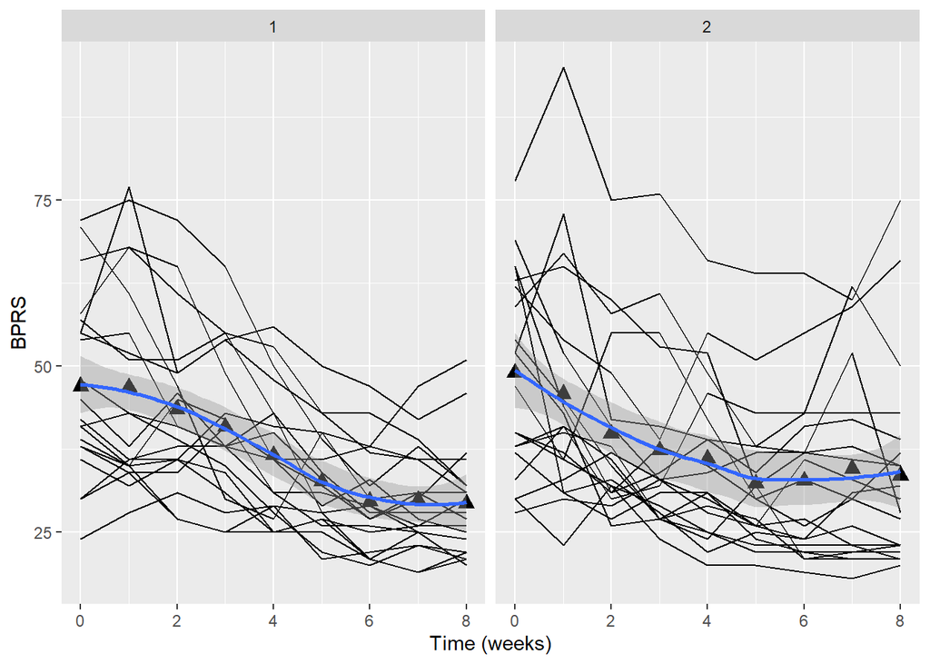

```r
ggplot(BPRSL, aes(x = week, y = bprs, group = subject)) +geom_line() + stat_summary(aes(group = 1), geom = "point", fun.y = mean, shape = 17, size = 3) + facet_grid(. ~ treatment) + scale_x_continuous(name = "Time (weeks)") +scale_y_continuous(name = "BPRS") + theme(legend.position = "none") + stat_smooth(aes(group = 1))
```

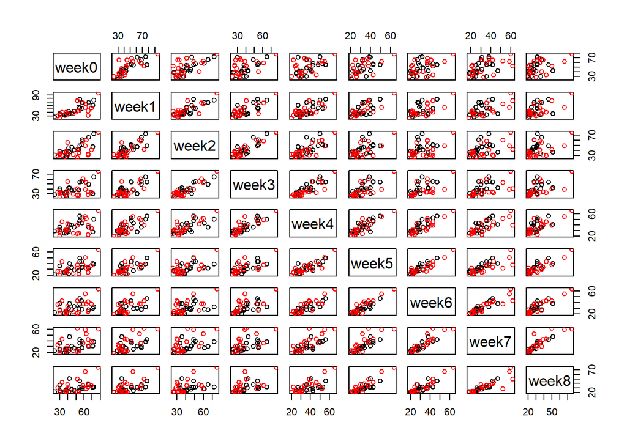

```r
pairs(BPRS[3:11],  col = BPRS$treatment)
```

Let’s run a simple linear regression that assumes that these repeated measures are independent

```r
BPRS_reg <- lm(bprs ~ week + treatment, data = BPRSL)


summary(BPRS_reg)
```

```
##
## Call:
## lm(formula = bprs ~ week + treatment, data = BPRSL)
##
## Residuals:
##     Min      1Q  Median      3Q     Max
## -22.454  -8.965  -3.196   7.002  50.244
##
## Coefficients:
##             Estimate Std. Error t value Pr(>|t|)
## (Intercept)  46.4539     1.3670  33.982   <2e-16 ***
## week         -2.2704     0.2524  -8.995   <2e-16 ***
## treatment2    0.5722     1.3034   0.439    0.661
## ---
## Signif. codes:  0 '***' 0.001 '**' 0.01 '*' 0.05 '.' 0.1 ' ' 1
##
## Residual standard error: 12.37 on 357 degrees of freedom
## Multiple R-squared:  0.1851, Adjusted R-squared:  0.1806
## F-statistic: 40.55 on 2 and 357 DF,  p-value: < 2.2e-16
```

A simple regression model tells us that there are no significant differences between groups based on treatment. But week is significant. This is because the model not aware of the repeated measures nature of the data.

```r
BPRS_ref <- lmer(bprs ~ week + treatment + (1 | subject), data = BPRSL, REML = FALSE)

summary(BPRS_ref)
```

```
## Linear mixed model fit by maximum likelihood  ['lmerMod']
## Formula: bprs ~ week + treatment + (1 | subject)
##    Data: BPRSL
##
##      AIC      BIC   logLik deviance df.resid
##   2748.7   2768.1  -1369.4   2738.7      355
##
## Scaled residuals:
##     Min      1Q  Median      3Q     Max
## -3.0481 -0.6749 -0.1361  0.4813  3.4855
##
## Random effects:
##  Groups   Name        Variance Std.Dev.
##  subject  (Intercept)  47.41    6.885
##  Residual             104.21   10.208
## Number of obs: 360, groups:  subject, 20
##
## Fixed effects:
##             Estimate Std. Error t value
## (Intercept)  46.4539     1.9090  24.334
## week         -2.2704     0.2084 -10.896
## treatment2    0.5722     1.0761   0.532
##
## Correlation of Fixed Effects:
##            (Intr) week
## week       -0.437
## treatment2 -0.282  0.000
```

Now lets add time (week) into the random effects.

```r
BPRS_ref1 <- lmer(bprs ~ week + treatment + (week | subject), data = BPRSL, REML = FALSE)

summary(BPRS_ref1)
```

```
## Linear mixed model fit by maximum likelihood  ['lmerMod']
## Formula: bprs ~ week + treatment + (week | subject)
##    Data: BPRSL
##
##      AIC      BIC   logLik deviance df.resid
##   2745.4   2772.6  -1365.7   2731.4      353
##
## Scaled residuals:
##     Min      1Q  Median      3Q     Max
## -2.8919 -0.6194 -0.0691  0.5531  3.7977
##
## Random effects:
##  Groups   Name        Variance Std.Dev. Corr
##  subject  (Intercept) 64.8222  8.0512
##           week         0.9609  0.9803   -0.51
##  Residual             97.4304  9.8707
## Number of obs: 360, groups:  subject, 20
##
## Fixed effects:
##             Estimate Std. Error t value
## (Intercept)  46.4539     2.1052  22.066
## week         -2.2704     0.2977  -7.626
## treatment2    0.5722     1.0405   0.550
##
## Correlation of Fixed Effects:
##            (Intr) week
## week       -0.582
## treatment2 -0.247  0.000
```

```r
anova(BPRS_ref1, BPRS_ref)
```

```
## Data: BPRSL
## Models:
## BPRS_ref: bprs ~ week + treatment + (1 | subject)
## BPRS_ref1: bprs ~ week + treatment + (week | subject)
##           Df    AIC    BIC  logLik deviance  Chisq Chi Df Pr(>Chisq)
## BPRS_ref   5 2748.7 2768.1 -1369.4   2738.7
## BPRS_ref1  7 2745.4 2772.6 -1365.7   2731.4 7.2721      2    0.02636 *
## ---
## Signif. codes:  0 '***' 0.001 '**' 0.01 '*' 0.05 '.' 0.1 ' ' 1
```

Compared to the previous model, the new model that includes both week and subject random effects is significantly better.

Finally let’s also add the interaction between week and treatment group variables (i.e. fixed effect).

```r
BPRS_ref2 <- lmer(bprs ~ week + treatment + (week * treatment)+ (week|subject), data = BPRSL, REML = FALSE)

summary(BPRS_ref2)
```

```
## Linear mixed model fit by maximum likelihood  ['lmerMod']
## Formula: bprs ~ week + treatment + (week * treatment) + (week | subject)
##    Data: BPRSL
##
##      AIC      BIC   logLik deviance df.resid
##   2744.3   2775.4  -1364.1   2728.3      352
##
## Scaled residuals:
##     Min      1Q  Median      3Q     Max
## -3.0512 -0.6271 -0.0768  0.5288  3.9260
##
## Random effects:
##  Groups   Name        Variance Std.Dev. Corr
##  subject  (Intercept) 64.9964  8.0620
##           week         0.9687  0.9842   -0.51
##  Residual             96.4707  9.8220
## Number of obs: 360, groups:  subject, 20
##
## Fixed effects:
##                 Estimate Std. Error t value
## (Intercept)      47.8856     2.2521  21.262
## week             -2.6283     0.3589  -7.323
## treatment2       -2.2911     1.9090  -1.200
## week:treatment2   0.7158     0.4010   1.785
##
## Correlation of Fixed Effects:
##             (Intr) week   trtmn2
## week        -0.650
## treatment2  -0.424  0.469
## wek:trtmnt2  0.356 -0.559 -0.840
```

```r
anova(BPRS_ref2, BPRS_ref1)
```

```
## Data: BPRSL
## Models:
## BPRS_ref1: bprs ~ week + treatment + (week | subject)
## BPRS_ref2: bprs ~ week + treatment + (week * treatment) + (week | subject)
##           Df    AIC    BIC  logLik deviance  Chisq Chi Df Pr(>Chisq)
## BPRS_ref1  7 2745.4 2772.6 -1365.7   2731.4
## BPRS_ref2  8 2744.3 2775.4 -1364.1   2728.3 3.1712      1    0.07495 .
## ---
## Signif. codes:  0 '***' 0.001 '**' 0.01 '*' 0.05 '.' 0.1 ' ' 1
```

This does not result in a significant improvement in our new model, which demonstrates that there is little or no interaction between treatment group and week variables.

In this model and all previous models, there was no significant difference in BPRS between treatment groups.

Let’s now draw a new plot based on our fitted model and compare it with the plot we drew at the beginning.

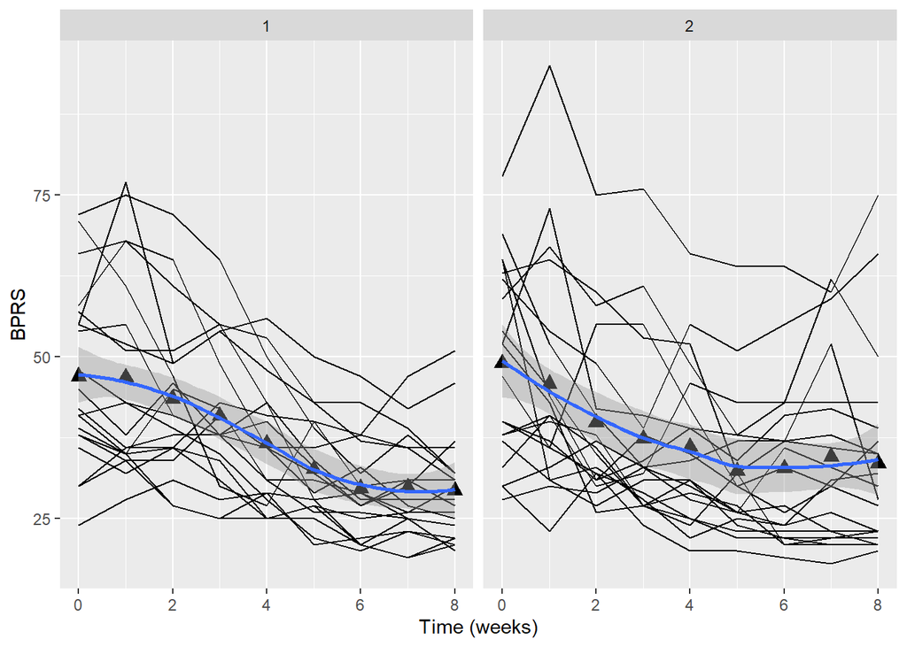

```r
ggplot(BPRSL, aes(x = week, y = bprs, group = subject)) +geom_line() + stat_summary(aes(group = 1), geom = "point", fun.y = mean, shape = 17, size = 3) + facet_grid(. ~ treatment) + scale_x_continuous(name = "Time (weeks)") +scale_y_continuous(name = "BPRS") + theme(legend.position = "none") + stat_smooth(aes(group = 1))
```

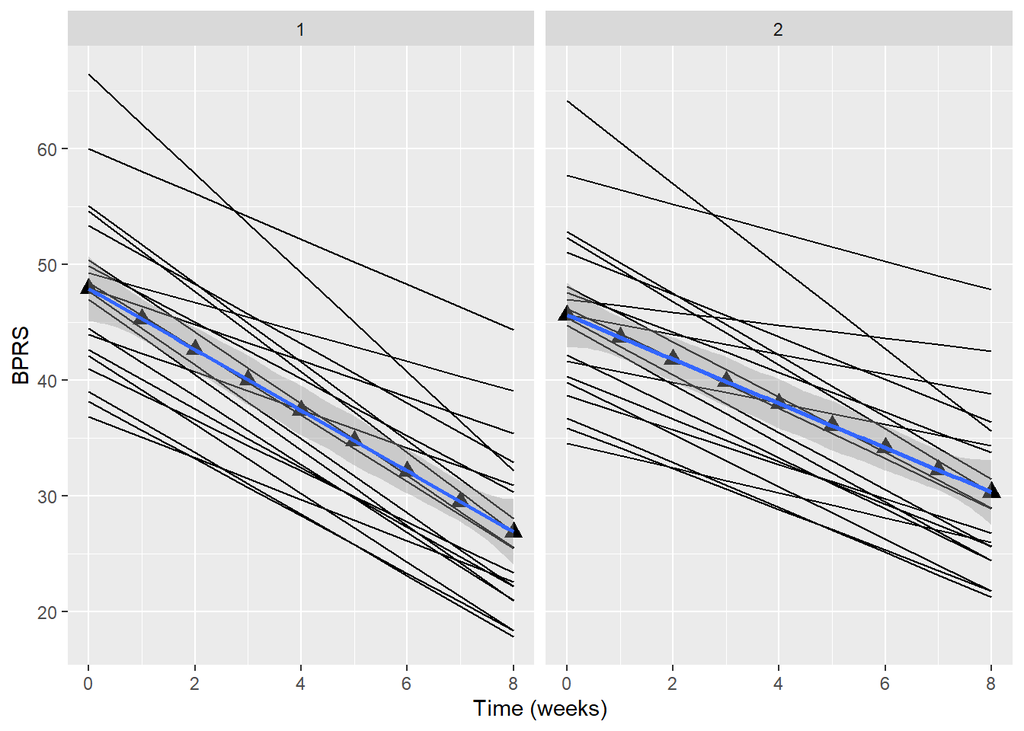

```r
Fitted <- fitted(BPRS_ref2)


BPRSL <- mutate(BPRSL, Fitted = Fitted)

ggplot(BPRSL, aes(x = week, y = Fitted, group = subject)) +geom_line() + stat_summary(aes(group = 1), geom = "point", fun.y = mean, shape = 17, size = 3) + facet_grid(. ~ treatment) + scale_x_continuous(name = "Time (weeks)") +scale_y_continuous(name = "BPRS") + theme(legend.position = "none") + stat_smooth(aes(group = 1))
```

Notice how the model fits regression lines for all individuals and also notice the final regression line is fitted. One can visually appreciate as well that there is no difference in BPRS scores between groups.